# Agglomerated Commuter Rail Survey Responses

Greg Macfarlane, Parsons Brinckerhoff

# 1 Introduction

This document presents a consolidated analysis of several surveys that included commuter rail system riders in the United States. The systems surveyed in this analysis are:

- Austin, Texas (MetroRail)
- Dallas, Texas (TRE)
- Miami, Florida (Tri Rail)
- Minneapolis, Minnesota
- Nashville, Tennesee
- Salt Lake City, Utah (FrontRunner)
- San Diego, California (Coaster)
- Washington, D.C. (MARC)

## 1.1 Data Construction

Each of these systems conducted an independent survey of its commuter rail passengers. For the most part, these were on-board surveys of only CRT passengers, but some surveys included other transit riders as well. Additionally, each survey used somewhat different variables, and different bins for other variables such as income and age. Further, the surveys categorized elements such as race, employment status, and fare category differently.

The attached `DataMaker` document contains detailed code on how I processed each set of survey responses and consolidated them into a single dataset, which I have stored as both an `Rdata` binary object and a `.csv` delimted text file.

```r
load("./Data/CommuterRail_Combined.Rdata")
```

### 1.1.1 Continuous Variable Fragmentation

As mentioned above, each survey used its own method of binning incomes; the survey respondents selected a range in which their income lay, and this range differed across surveys. In `DataMaker` I coded these categories as numerical values defined by the midpoint of the range. Some of the figures in this document will look more natural if I fragment these variables, randomly incorporating the measurement error inherent with such a data collection method. So to each income and age field I add a uniformly distributed random number of plus or minus 15 percent of the given income or age.

> Note: some cities actually did ask for the age of the respondent explicity; in these cases I did not add the random number to the age.

```r
incerror <- 0.15

CRTsurveys <- CRTsurveys %>%
  mutate(income = runif(n = n(), min = (1 - incerror) * income,
                         max = (1 + incerror) * income),
         rage = runif(n = n(), min = (1 - incerror) * age,
                         max = (1 + incerror) * age),
         # Austin, San Diego ask age explicitly
         age = ifelse(city %in% c("Austin", "San Diego"), age, rage)) %>%
  select(-rage)
```

## 1.2 Total system ridership and weights

Each survey came with its own linked-trip expansion weights, which I have placed in the `weight` variable. The sum of these weights gives the total system ridership.

```r
kable(CRTsurveys %>% group_by(city) %>%
        summarise(ridership = sum(weight)), digits = 0)
```

| city | ridership |
| --- | --- |
| Austin | 1263 |
| Dallas | 9017 |
| Miami | 12200 |
| Minneapolis | 6066 |
| Nashville | 872 |
| San Diego | 4733 |
| Salt Lake | 5385 |
| Washington | 26326 |

For density plots where we show the relative share by system, we need a set of weights where the city sums to one, or Washington will dominate smaller systems like Austin and Nashville.

```r
CRTsurveys <- CRTsurveys %>% group_by(city) %>%
  mutate(cityweight = weight / sum(weight))
```

# 2 Commuter Rail Rider Profile

## 2.1 Income

On the whole, the survey respondents are middle- to upper-income, with the national mode of the distribution being in the range of 50k$ per year. We should not read too much into this graphic, however, because it may be that regions with higher average incomes may have had higher response to the survey.

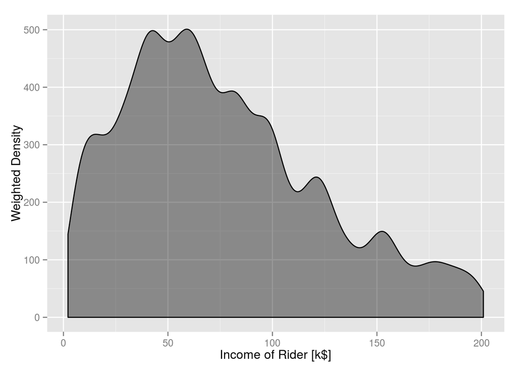

```r
ggplot(CRTsurveys, aes(x = income/1000, weight = weight)) +
  geom_density(fill = "black", alpha = 0.4) + xlab("Income of Rider [k$]") +
  ylab("Weighted Density")
```

In most cases, there is a hump on the right side of the distribution because the survey categories censored too many high incomes. Washington D.C. has a very high relative income for its commuter rail passengers, but this may be a function of high average incomes in the general population, as well as the coverage of the overall transit network.

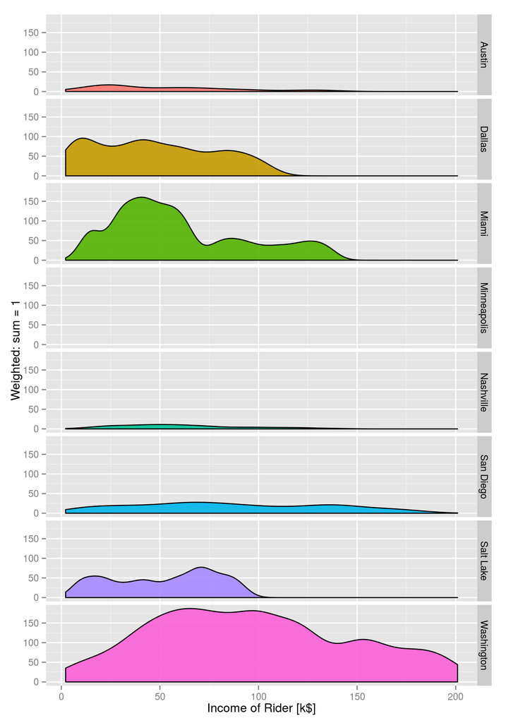

```r
ggplot(CRTsurveys, aes(x = income/1000, fill = city, weight = weight)) +
  geom_density(alpha = 0.9) + xlab("Income of Rider [k$]")+
  facet_grid(city ~ .) + theme(legend.position = "none") +
  ylab("Weighted: sum = 1")
```

The above figure uses the given weights, so the integral of the density curve sums to the system ridership. The figure below scales the weights so that the integral sums to one. This may be better for comparison across systems.

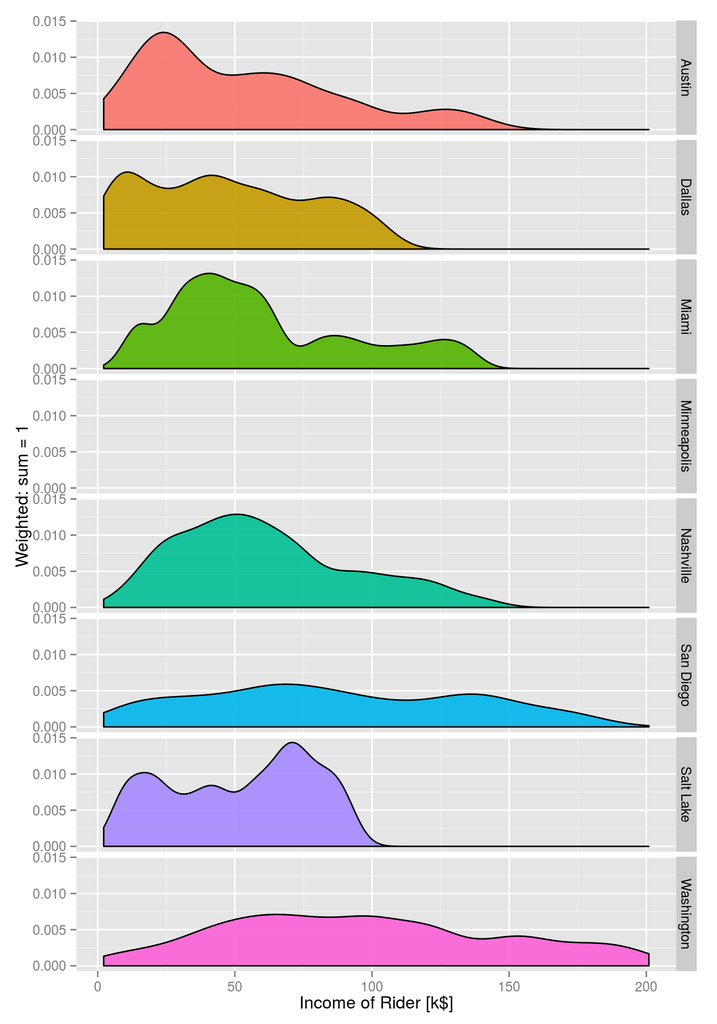

```r
ggplot(CRTsurveys, aes(x = income/1000, fill = city, weight = cityweight)) +
  geom_density(alpha = 0.9) + xlab("Income of Rider [k$]")+
  facet_grid(city ~.) + theme(legend.position = "none") +
  ylab("Weighted: sum = 1")
```

### 2.1.1 Income by Group

The table and chart below show basically the same information, but this time by percent in income groups rather than density.

```r
income_groups <- CRTsurveys %>%
  mutate(
    income_group = cut(income,
                       breaks = c(0, 25, 50, 84, Inf) * 1000,
                       labels = c("<25k", "25-50k", "50-84k", ">84k"))
  ) %>%
  filter(!is.na(income_group)) %>%
  group_by(income_group, city) %>%
  summarise(n = sum(weight)) %>%
  group_by(city) %>%
  mutate(n = n / sum(n) * 100)

income_groups %>%
  spread(income_group, n) %>%
  kable(caption = "Share of riders by income.")
```

Share of riders by income.

| city | <25k | 25-50k | 50-84k | >84k |
| --- | --- | --- | --- | --- |
| Austin | 28.823291 | 25.07845 | 26.72116 | 19.37710 |
| Dallas | 28.343778 | 27.99561 | 28.90873 | 14.75188 |
| Miami | 9.670243 | 38.27663 | 27.75797 | 24.29516 |
| Nashville | 11.566160 | 29.31374 | 35.12942 | 23.99067 |
| San Diego | 12.723071 | 13.32512 | 26.58612 | 47.36568 |
| Salt Lake | 22.851893 | 22.21319 | 43.24528 | 11.68964 |
| Washington | 6.311556 | 12.86608 | 25.25864 | 55.56373 |

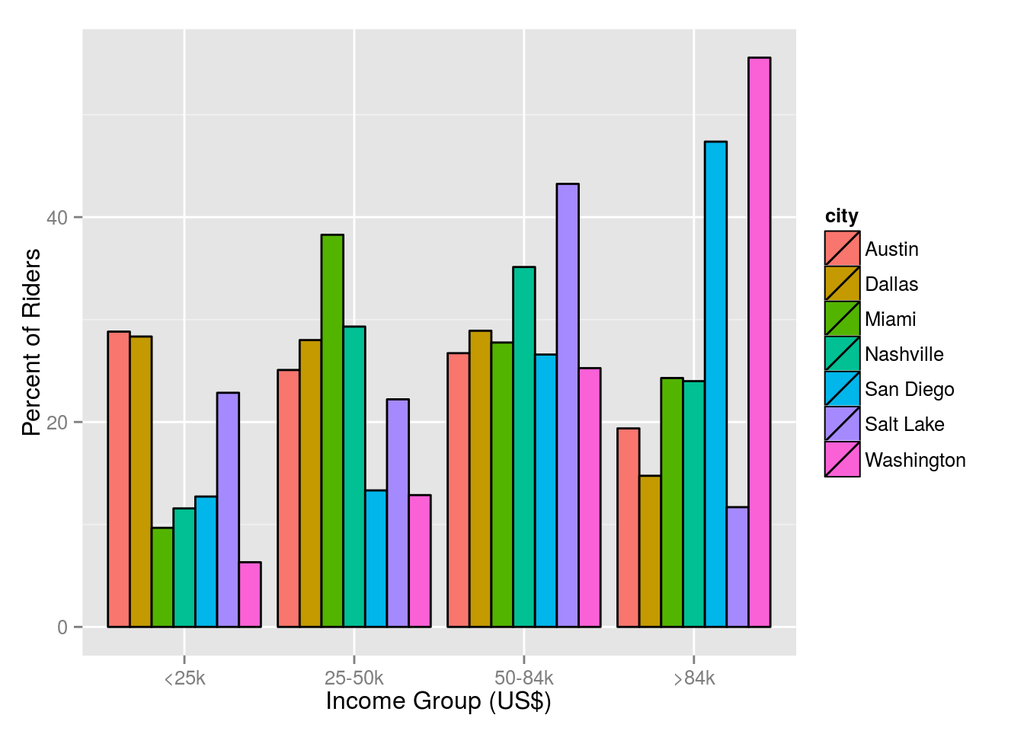

```r
ggplot(income_groups, aes(x = income_group, y = n, fill = city)) +
  geom_bar(stat = "identity", position = "dodge", color = "black") +
  xlab("Income Group (US$)") + ylab("Percent of Riders")
```

## 2.2 Age

On the whole, commuter rail riders tend to represent working ages well, with perhaps more young riders in some cities. The mode of the distribution appears to be somewhere around 40 years old. The distribution also drops off quickly around retirement age.

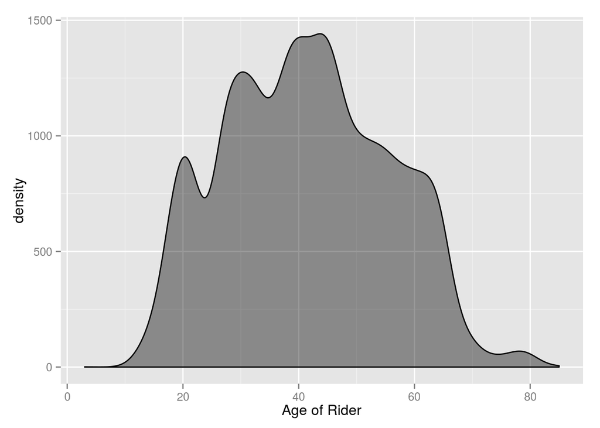

```r
ggplot(CRTsurveys, aes(x = age, weight = weight)) +
  geom_density(fill = "black", alpha = 0.4) +
  xlab("Age of Rider")
```

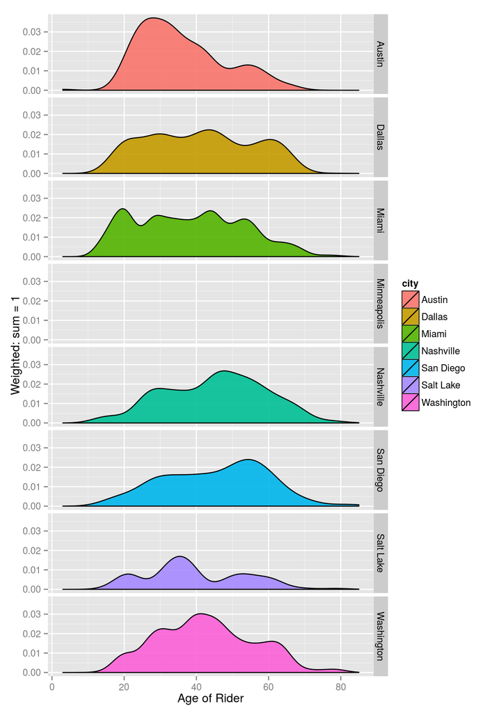

```r
ggplot(CRTsurveys, aes(x = age, fill = city, weight = cityweight)) +
  geom_density(alpha = 0.9) + xlab("Age of Rider")+
  facet_grid(city ~ .) + ylab("Weighted: sum = 1")
```

## 2.3 Ethnicity

The preponderance of CRT riders in all cities are White. Aside from this it is difficult to make comparative statements across regions, as the ethnic distribution in the population as a whole is unknown. That said, I would have expected more Black riders in Nashville.

Further neither San Diego nor Salt Lake City asked about the respondents’ race.

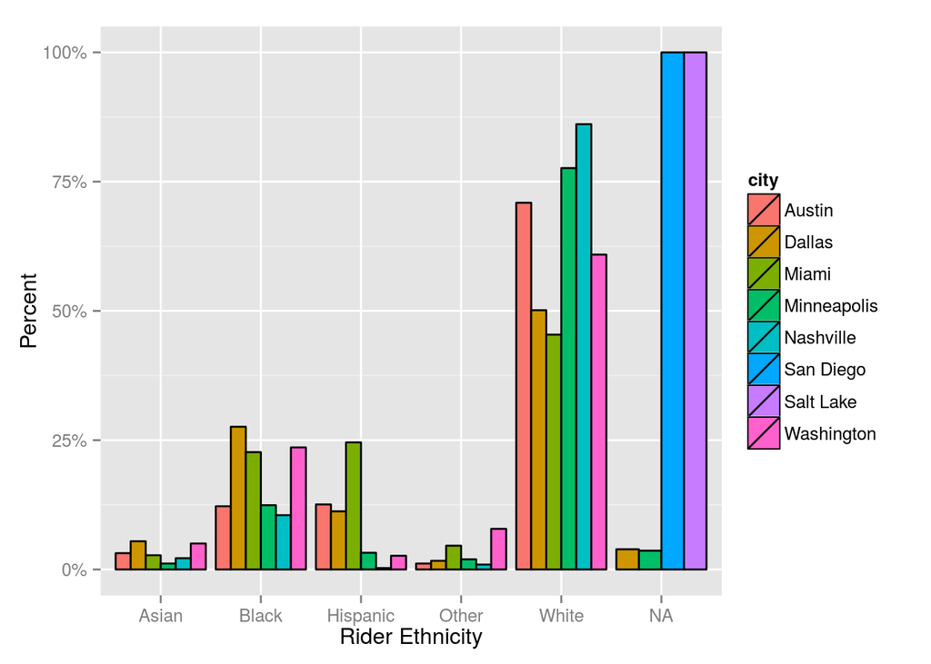

```r
ggplot(CRTsurveys, aes(x = race, weight = cityweight)) +
  geom_bar(position = "dodge", aes(y = ..count.., fill = city, group = city),
           color = "black") +
  xlab("Rider Ethnicity") + scale_y_continuous(labels = percent) +
  ylab("Percent")
```

## 2.4 Gender

The gender split of commuter rail riders is interesting, though again it may be more indicative of cultural trends in the region than a characteristic of commuter rail riders in general.

I am curious why so many more women than men ride commuter rail in Nashville and Minneapolis.

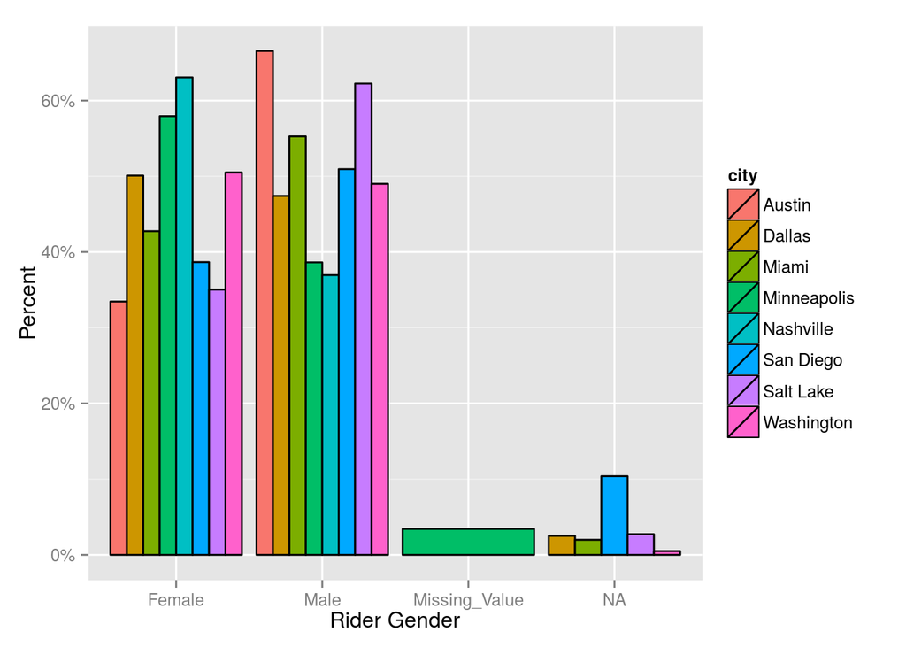

```r
ggplot(CRTsurveys, aes(x = sex, weight = cityweight)) +
  geom_bar(position = "dodge", aes(y = ..count.., fill = city, group = city),
           color = "black") +
  xlab("Rider Gender") + scale_y_continuous(labels = percent) +
  ylab("Percent")
```

## 2.5 Choice and Vehicle

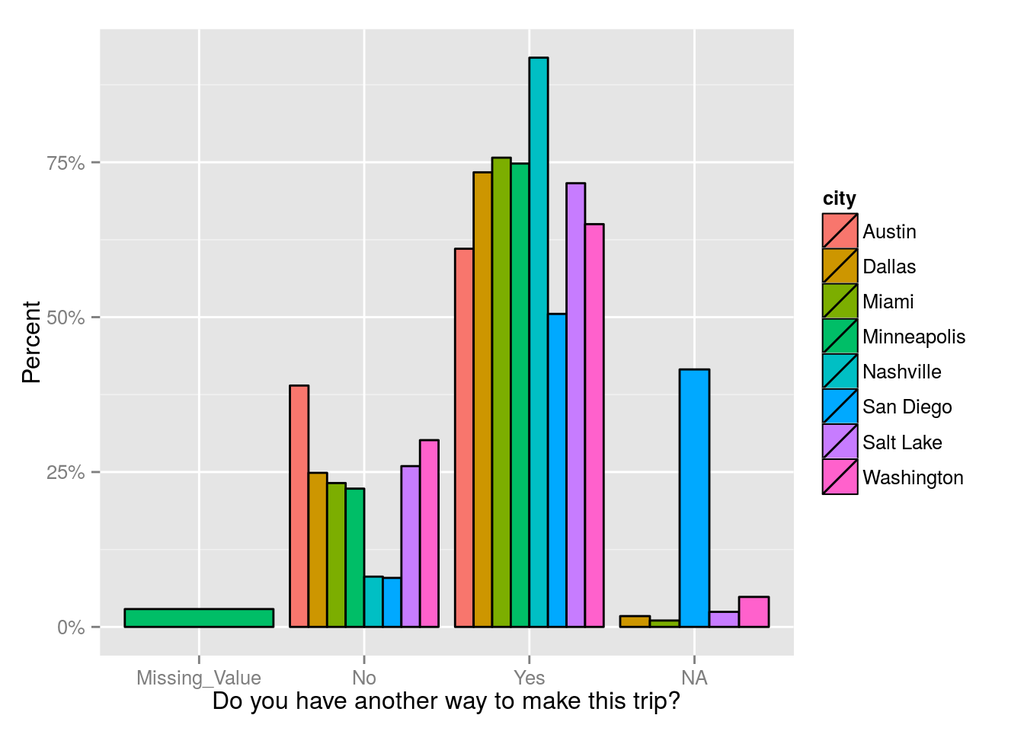

```r
ggplot(CRTsurveys, aes(x = choicerider, weight = cityweight)) +
  geom_bar(position = "dodge", aes(y = ..count.., fill = city, group = city),
           color = "black") +
  xlab("Do you have another way to make this trip?") +
  scale_y_continuous(labels = percent) +
  ylab("Percent")
```

> Personal footnote: high numbers of choice riders show that transit is getting cars off the road, but also that the system may not be designed for people in the community who need to use it.

The surveys also ask about the households size, and the number of vehicles available to the household. *Note: the surveys are not consistent. Some ask* *about number of people over 15, or number of adults, or total number.* In the following figure, we see the difference between vehicles and household size by city.

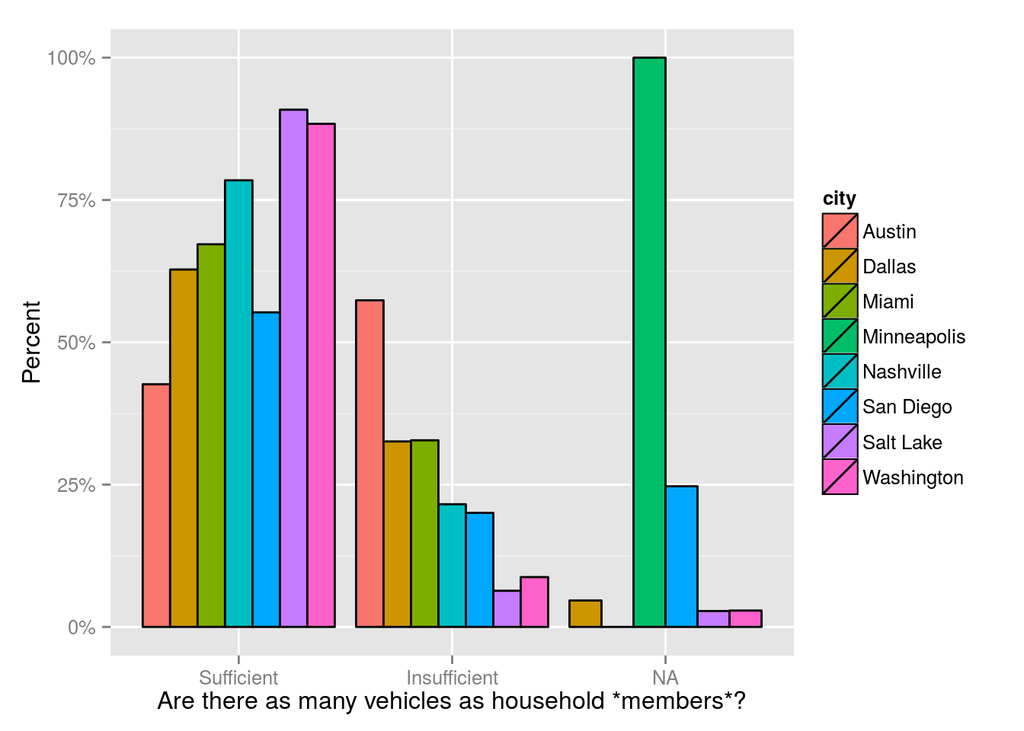

```r
CRTsurveys <- CRTsurveys %>%
  mutate(sufficient = cut(hhsize - cars, breaks = c(-Inf, 1, Inf),
                          labels = c("Sufficient", "Insufficient")))
ggplot(CRTsurveys, aes(x = sufficient, weight = cityweight, fill = city)) +
  geom_bar(position = "dodge", aes(y = ..count..,  group = city),
           color = 'black') +
  xlab("Are there as many vehicles as household *members*?") +
  scale_y_continuous(labels = percent) +
  ylab("Percent")
```

```r
car_groups <- CRTsurveys %>% ungroup() %>%
  mutate(
    cars = ifelse(cars > 2, 2, cars),
    cars = ifelse(cars < 0, 0, cars)
  ) %>%
  filter(!is.na(cars)) %>%
  group_by(cars, city) %>%
  summarise(n = sum(weight)) %>%
  group_by(city) %>%
  mutate(n = n / sum(n) * 100)

car_groups %>%
  spread(cars, n)  %>%
  kable(caption = "Share of riders by vehicle ownership.")
```

Share of riders by vehicle ownership.

| city | 0 | 1 | 2 |
| --- | --- | --- | --- |
| Austin | 20.007703 | 29.63195 | 50.36035 |
| Dallas | 17.898364 | 27.97793 | 54.12371 |
| Miami | 5.182866 | 26.13470 | 68.68243 |
| Minneapolis | 10.322738 | 19.10463 | 70.57263 |
| Nashville | 2.192273 | 32.21803 | 65.58969 |
| San Diego | 9.937185 | 25.34210 | 64.72072 |
| Salt Lake | 6.451981 | 18.69786 | 74.85016 |
| Washington | 6.214182 | 30.80615 | 62.97966 |

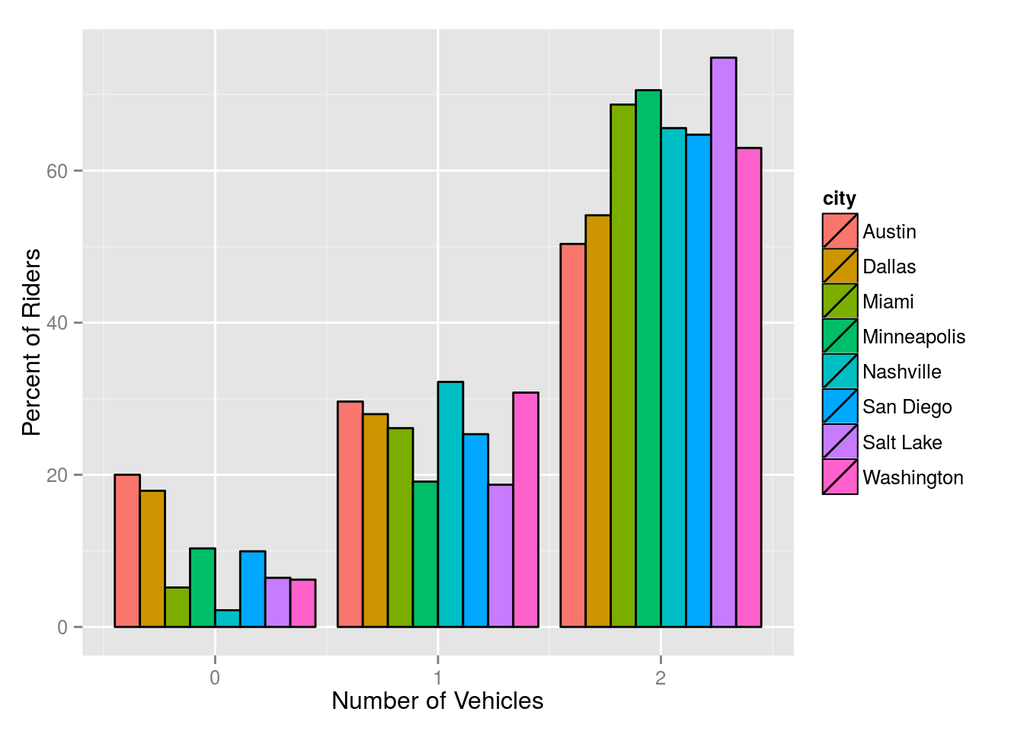

```r
ggplot(car_groups, aes(x = cars, y = n, fill = city)) +
  geom_bar(stat = "identity", position = "dodge", color = "black") +
  xlab("Number of Vehicles") + ylab("Percent of Riders")
```

#### 2.5.0.1 Vehicle Ownership by Trip Purpose

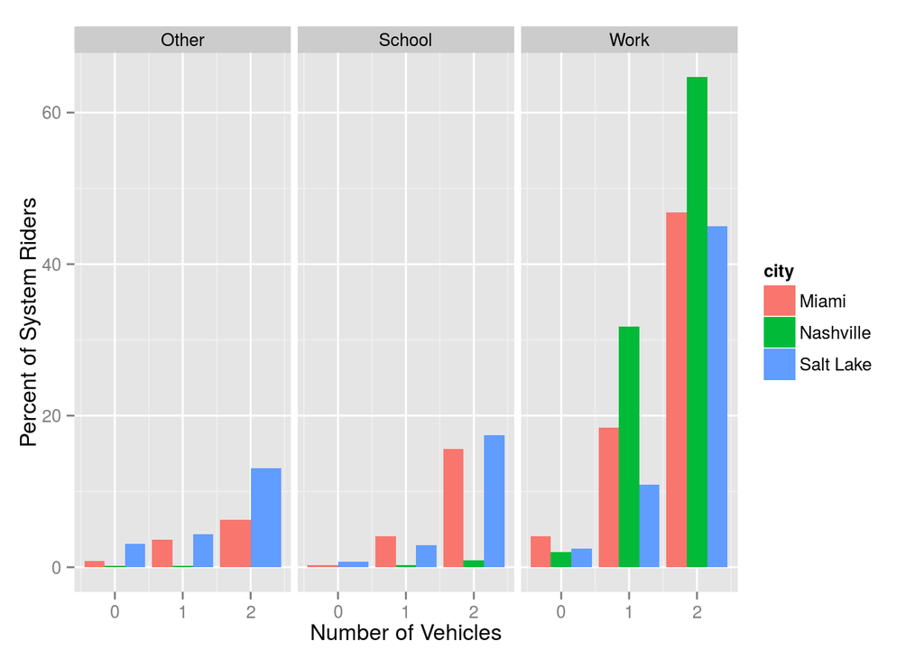

```r
purposes_by_vehicle <- CRTsurveys %>% ungroup() %>%
  mutate(
    cars = ifelse(cars > 2, 2, cars),
    cars = ifelse(cars < 0, 0, cars)
  ) %>%
  filter(
    !is.na(cars),
    atype != "Home",
    city %in% c("Miami", "Salt Lake", "Nashville")
  ) %>%
  group_by(cars, city, atype) %>%
  summarise(n = sum(weight)) %>%
  group_by(city) %>%
  mutate(n = n / sum(n) * 100)

ggplot(purposes_by_vehicle, aes(x = cars, y = n, fill = city)) +
  geom_bar(stat = "identity", position = "dodge") +
  facet_grid(. ~ atype) +
  xlab("Number of Vehicles") + ylab("Percent of System Riders")
```

# 3 Use Patterns

## 3.1 Trip Purpose

The tables below give trip purpose as determined by a combination of production and attraction type. The `Other` category includes shopping, medical visits, recreation and personal activities, etc. The production type is given in the rows and the attractions in the columns.

```r
# Raw numbers, using given weights
purptable <- wtd.table(CRTsurveys$ptype, CRTsurveys$atype,
                       weights = CRTsurveys$weight)
kable(purptable, digits = 0)
```

|  | Home | Other | School | Work |
| --- | --- | --- | --- | --- |
| Home | 188 | 6335 | 6004 | 46483 |
| Other | 0 | 1855 | 219 | 711 |
| School | 0 | 426 | 250 | 120 |
| Work | 0 | 967 | 363 | 836 |

```r
# Percent, using given weights
kable(purptable/sum(CRTsurveys$weight)* 100, digits = 2)
```

|  | Home | Other | School | Work |
| --- | --- | --- | --- | --- |
| Home | 0.29 | 9.62 | 9.12 | 70.58 |
| Other | 0.00 | 2.82 | 0.33 | 1.08 |
| School | 0.00 | 0.65 | 0.38 | 0.18 |
| Work | 0.00 | 1.47 | 0.55 | 1.27 |

### 3.1.1 By city

> Note that in some cases trips are “attracted” to a home. This occurs when 1) a trip is coded as `Home` to `Home` or 2) the source data is explicitly coded as P and A.

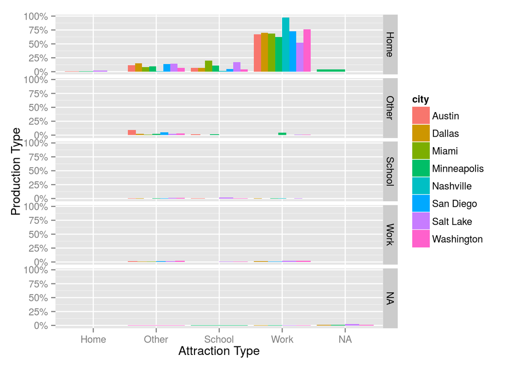

```r
ggplot(CRTsurveys, aes(x = atype, fill = city, weight = cityweight)) +
  geom_bar(position = "dodge", aes(y = ..count.., group = city)) +
  scale_y_continuous(labels = percent) +
  facet_grid(ptype ~ .) +
  ylab("Production Type") + xlab("Attraction Type")
```

## 3.2 Access Mode

```r
# Raw numbers, weighted
accesstable <- wtd.table(CRTsurveys$paccessmode, CRTsurveys$aaccessmode,
                         weights = CRTsurveys$weight)
accesstable <- rbind(accesstable, colSums(accesstable))
accesstable <- cbind(accesstable, rowSums(accesstable))
rownames(accesstable)[7] <- colnames(accesstable)[7] <- "Sum"
# Raw numbers
kable(accesstable, digits = 0 )
```

|  | Bike | Bus | Car | PU_DO | Rail | Walk | Sum |
| --- | --- | --- | --- | --- | --- | --- | --- |
| Bike | 224 | 298 | 33 | 0 | 98 | 41 | 693 |
| Bus | 249 | 1560 | 1404 | 312 | 633 | 2878 | 7035 |
| Car | 65 | 8374 | 4364 | 1057 | 8620 | 10661 | 33140 |
| PU_DO | 0 | 2108 | 530 | 1015 | 1520 | 2079 | 7252 |
| Rail | 11 | 766 | 259 | 409 | 311 | 943 | 2698 |
| Walk | 0 | 2176 | 301 | 359 | 1584 | 3287 | 7707 |
| Sum | 548 | 15281 | 6891 | 3152 | 12766 | 19888 | 58526 |

```r
#Percents
kable(accesstable/sum(CRTsurveys$weight) * 100, digits = 1)
```

|  | Bike | Bus | Car | PU_DO | Rail | Walk | Sum |
| --- | --- | --- | --- | --- | --- | --- | --- |
| Bike | 0.3 | 0.5 | 0.1 | 0.0 | 0.1 | 0.1 | 1.1 |
| Bus | 0.4 | 2.4 | 2.1 | 0.5 | 1.0 | 4.4 | 10.7 |
| Car | 0.1 | 12.7 | 6.6 | 1.6 | 13.1 | 16.2 | 50.3 |
| PU_DO | 0.0 | 3.2 | 0.8 | 1.5 | 2.3 | 3.2 | 11.0 |
| Rail | 0.0 | 1.2 | 0.4 | 0.6 | 0.5 | 1.4 | 4.1 |
| Walk | 0.0 | 3.3 | 0.5 | 0.5 | 2.4 | 5.0 | 11.7 |
| Sum | 0.8 | 23.2 | 10.5 | 4.8 | 19.4 | 30.2 | 88.9 |

Access on the attraction end (or egress) is predominantly by walking or another transit mode.

> note that the percents in the table do not sum to 1; this is because of missing data.

### 3.2.1 By City

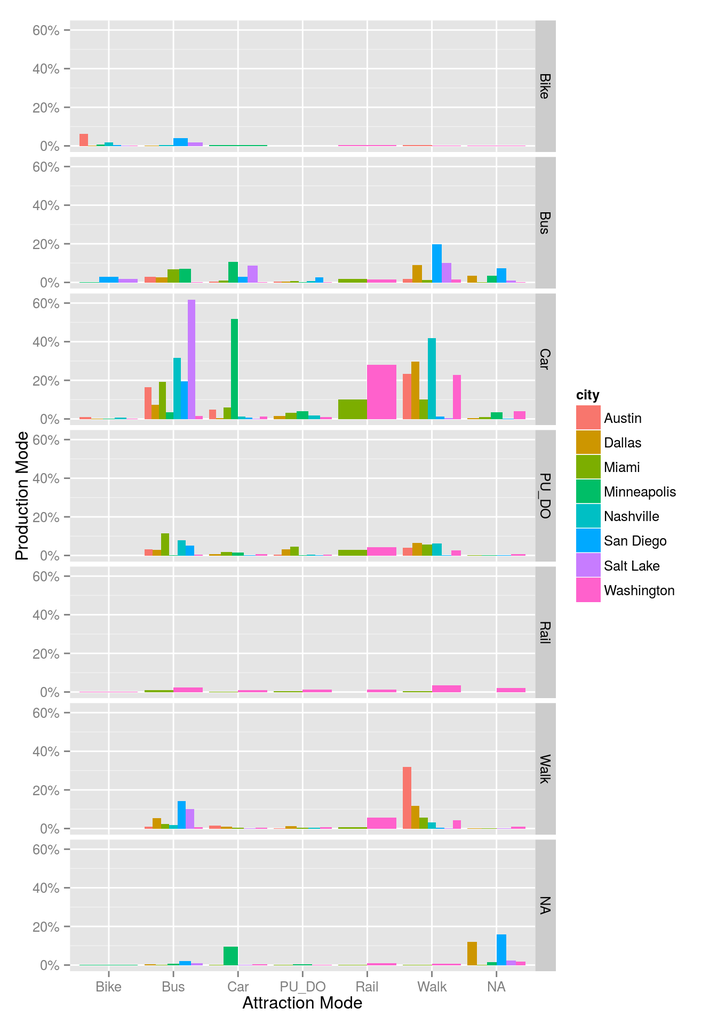

```r
ggplot(CRTsurveys, aes(x = aaccessmode, fill = city, weight = cityweight)) +
  geom_bar(position = "dodge", aes(y = ..count.., group = city))+
  scale_y_continuous(labels = percent) +
  facet_grid(paccessmode ~ .) +
  ylab("Production Mode") + xlab("Attraction Mode")
```

## 3.3 Trip Frequency

One question frequently asked in the surveys concerns the frequency of use, and whether this was the first time the respondent had used the commuter rail. To compare these answers as a numerical variable, we converted them to an expectation of occurrence on a workday. For example, if someone said they took CRT “1-2 times per month”, we convert this to $1.5/20 = 0.075$; similarly, “Three times per week” becomes $3/5 = 0.6$. (Note that if someone says they take CRT 6 or 7 days a week the probability is greater than 1.)

Unsurprisingly, most CRT riders tend to be habitual, using it every day. At the same time, there are significant numbers who take it only occasionally.

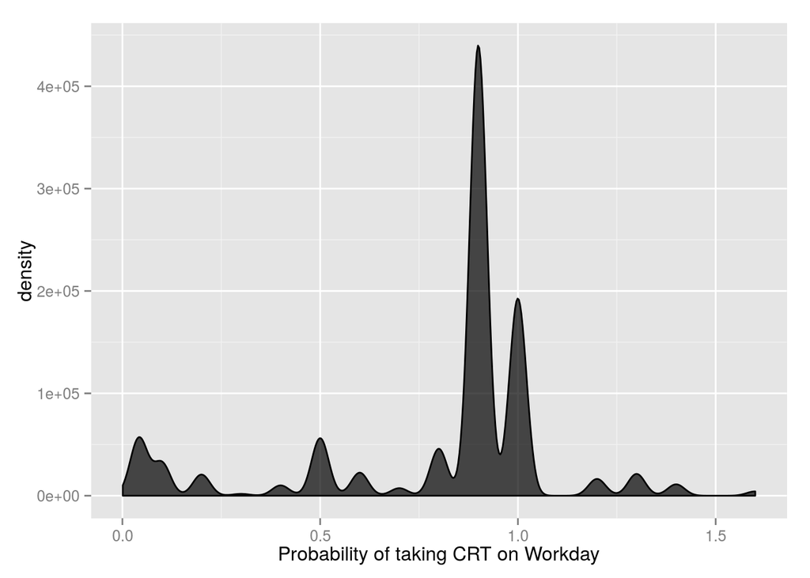

```r
ggplot(CRTsurveys, aes(x = freq, weight = weight)) +
  geom_density(fill = "black", alpha = 0.7) +
  xlab("Probability of taking CRT on Workday")
```

> Note: San Diego did not ask about trip frequency

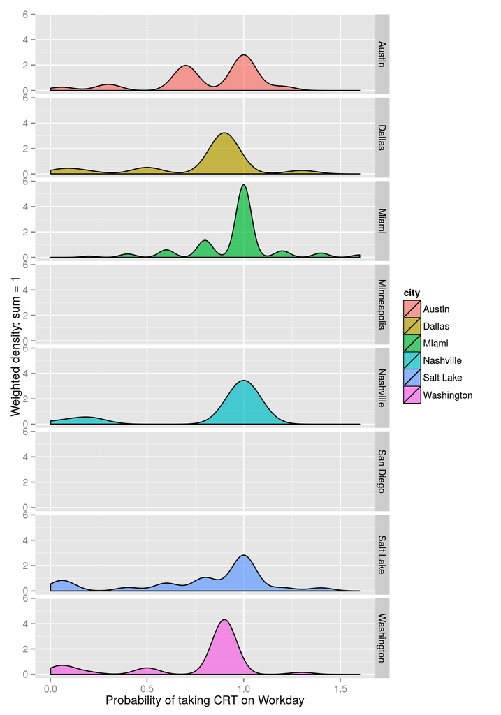

```r
ggplot(CRTsurveys, aes(x = freq, fill = city, weight = cityweight)) +
  geom_density(alpha = 0.7) + facet_grid(city ~.) +
  xlab("Probability of taking CRT on Workday") +
  ylab("Weighted density: sum = 1")
```

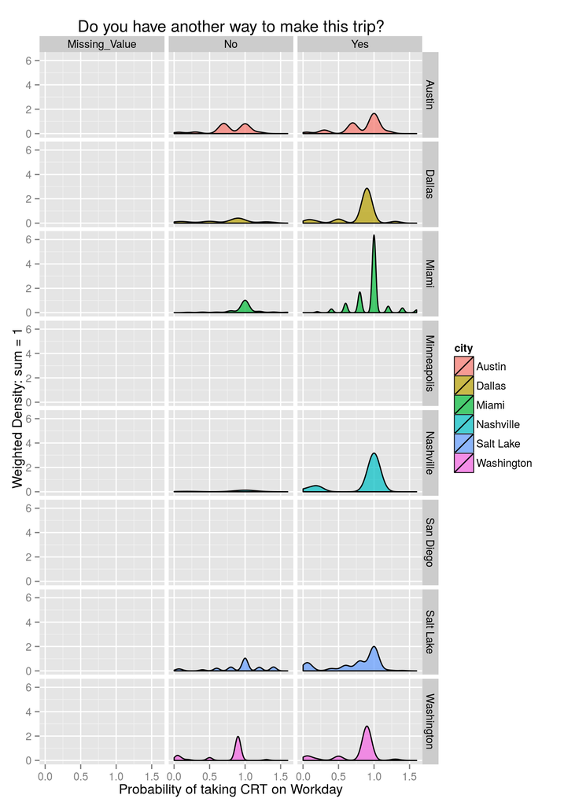

```r
ggplot(filter(CRTsurveys, !(is.na(choicerider))),
       aes(x = freq, fill = city, weight = cityweight)) +
  geom_density(alpha = 0.7) +
  ggtitle("Do you have another way to make this trip?")  +
  xlab("Probability of taking CRT on Workday") +
  ylab("Weighted Density: sum = 1") +
  facet_grid(facet = city ~ choicerider)
```

We can also look at sufficiency plotted against frequency. The least-squares regression fit by city is also superimposed on the plot. For most cities we cannot reject that there is no relationship between sufficiency and trip frequency. In Washington, there appears to be a relationship where as insufficiency increases (there are more people than cars), trip frequency goes *down*. Salt Lake shows the exact opposite relationship, with trip frequency and insufficiency increasing together.

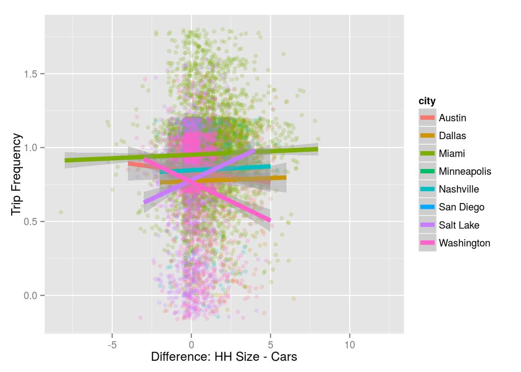

```r
ggplot(CRTsurveys, aes(x = hhsize - cars, y = freq, color = city,
                       weight = cityweight)) +
  geom_jitter(alpha = 0.2,
              position = position_jitter(width = 0.5, height = 0.2)) +
  stat_smooth(method = "lm", lwd = 2) +
  xlab("Difference: HH Size - Cars") + ylab("Trip Frequency")
```

## 3.4 Purpose and Access Mode by Auto Ownership

How much does vehicle availability determine the production mode? We’re only worried about trips produced at home.

```r
purpose_mode_ownership <- CRTsurveys %>%
  filter(ptype == "Home") %>%
  filter(atype != "Home") %>%
  filter(!is.na(cars)) %>%
  filter(!is.na(income)) %>%
  filter(!is.na(atype)) %>%
  filter(!is.na(paccessmode)) %>%
  mutate( cars = ifelse(cars >= 2, "2 +", cars) ) %>%

  # weighted surveys in each group
  group_by(city, cars, paccessmode, atype) %>%
  summarise(n = sum(weight))
```

```r
purpose_mode_ownership %>%
  group_by(atype, cars, paccessmode) %>%
  summarise(n = sum(n)) %>%
  group_by(atype, cars) %>%
  mutate(n = n / sum(n)) %>%
  spread(paccessmode, n, fill = 0) %>%
  kable(., caption = "Access mode share by attraction type and vehicle ownership")
```

Access mode share by attraction type and vehicle ownership

| atype | cars | Bike | Bus | Car | PU_DO | Rail | Walk |
| --- | --- | --- | --- | --- | --- | --- | --- |
| Other | 0 | 0.0108015 | 0.2223516 | 0.0790108 | 0.0672999 | 0.1117832 | 0.5087531 |
| Other | 1 | 0.0085691 | 0.1408879 | 0.3574384 | 0.1697729 | 0.0995635 | 0.2237682 |
| Other | 2 + | 0.0018412 | 0.1087117 | 0.6009711 | 0.1311647 | 0.0602703 | 0.0970409 |
| School | 0 | 0.0149724 | 0.3335665 | 0.0284271 | 0.3590456 | 0.0000000 | 0.2639885 |
| School | 1 | 0.0056842 | 0.1074275 | 0.2731151 | 0.3093695 | 0.1888052 | 0.1155986 |
| School | 2 + | 0.0014727 | 0.0785442 | 0.5801013 | 0.2183512 | 0.0325446 | 0.0889861 |
| Work | 0 | 0.0266369 | 0.4531028 | 0.0524005 | 0.0481232 | 0.0905812 | 0.3291555 |
| Work | 1 | 0.0135020 | 0.1058427 | 0.4975335 | 0.1415070 | 0.0738818 | 0.1677330 |
| Work | 2 + | 0.0104278 | 0.0719631 | 0.7307035 | 0.0894062 | 0.0187584 | 0.0787411 |

```r
purpose_mode_ownership %>%
  filter(city %in% c("Nashville", "Miami")) %>%
  group_by(atype, cars, paccessmode) %>%
  summarise(n = sum(n)) %>%
  group_by(atype, cars) %>%
  #mutate(n = n / sum(n)) %>%
  spread(paccessmode, n, fill = 0) %>%
  kable(., digits = 2, caption = "Nashville and Miami: Access mode share by attraction type and vehicle ownership")
```

| atype | cars | Bike | Bus | Car | PU_DO | Rail | Walk |
| --- | --- | --- | --- | --- | --- | --- | --- |
| Other | 0 | 0.00 | 36.68 | 0.00 | 10.94 | 0.00 | 19.21 |
| Other | 1 | 0.00 | 53.51 | 100.93 | 80.98 | 41.06 | 15.56 |
| Other | 2 + | 0.00 | 54.91 | 365.64 | 90.02 | 5.50 | 5.27 |
| School | 0 | 0.00 | 28.10 | 0.00 | 2.91 | 0.00 | 0.00 |
| School | 1 | 0.00 | 34.83 | 98.90 | 155.59 | 0.00 | 57.52 |
| School | 2 + | 0.00 | 35.19 | 491.50 | 312.34 | 7.33 | 86.70 |
| Work | 0 | 0.00 | 186.61 | 7.37 | 76.45 | 14.39 | 195.79 |
| Work | 1 | 6.43 | 325.25 | 1146.75 | 619.01 | 64.30 | 243.66 |
| Work | 2 + | 12.80 | 303.81 | 4055.21 | 809.10 | 64.36 | 458.27 |

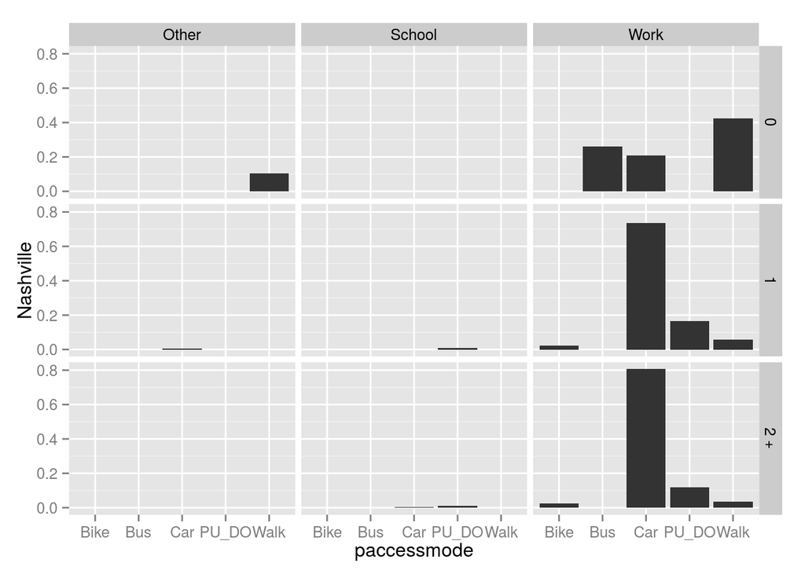

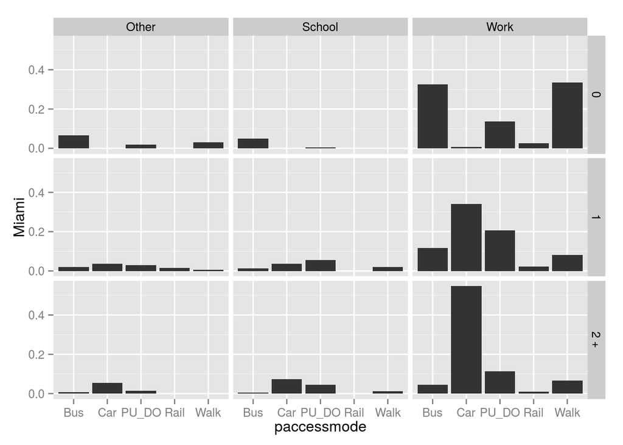

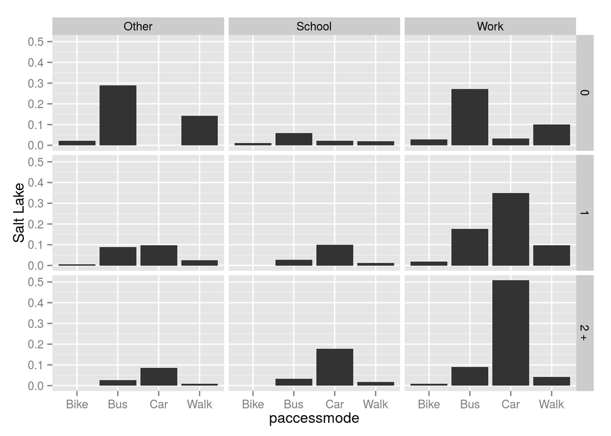

```r
for(i in c("Nashville", "Miami", "Salt Lake")){
y <- ggplot(purpose_mode_ownership %>%
         filter(city == i) %>%
         group_by(city, cars) %>%
         mutate(n = n / sum(n)),
       aes(x = paccessmode, y = n)) +
  geom_bar(position = "dodge", stat = "identity") +
  facet_grid(cars ~ atype) +
  ylab(i)
  print(y)
}
```

### 3.4.1 By city

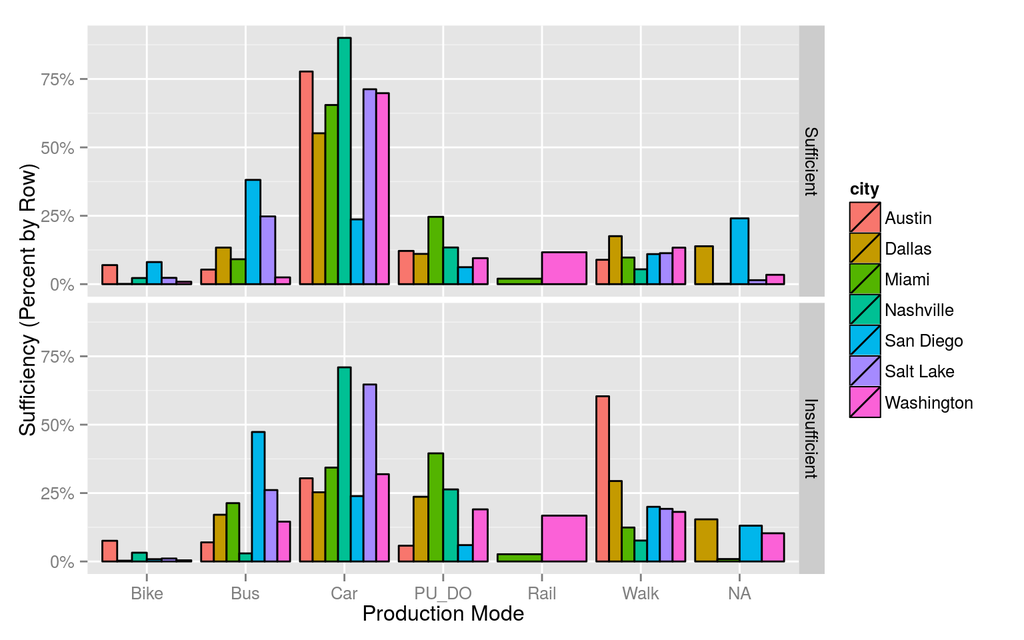

```r
ggplot(filter(CRTsurveys, !(is.na(sufficient))),
       aes(x = paccessmode, fill = city, weight = cityweight)) +
  geom_bar(position = "dodge", aes(y = ..density.., group = city),
           color = "black") + facet_grid(sufficient ~ .) +
  xlab("Production Mode") +
  ylab("Sufficiency (Percent by Row)") + scale_y_continuous(labels = percent)
```

## 3.5 Peak Period Travel

The chart below shows peak and off-peak travel by city. In most cities there is a strong bias towards peak travel with more than 50 of riders in modst cities traveling in the peak period. Austin and Salt Lake City have the most peaked distribution, and Washington and Dallas have the highest off-peak shares.

When the survey data included the specific time of the trip, I called peak trips those happening between 7-10 AM and 4-7 PM. Some surveys, however, only included their own internal definitions of peak period, so it is possible that these data are not fully comparable.

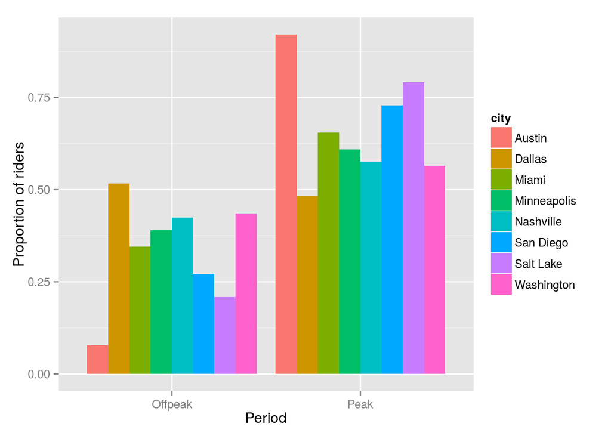

```r
ggplot(CRTsurveys, aes(x = period, fill = city, weight = cityweight)) +
  geom_bar(position = "dodge", aes(y = ..count.., group = city)) +
  xlab("Period") + ylab("Proportion of riders")
```

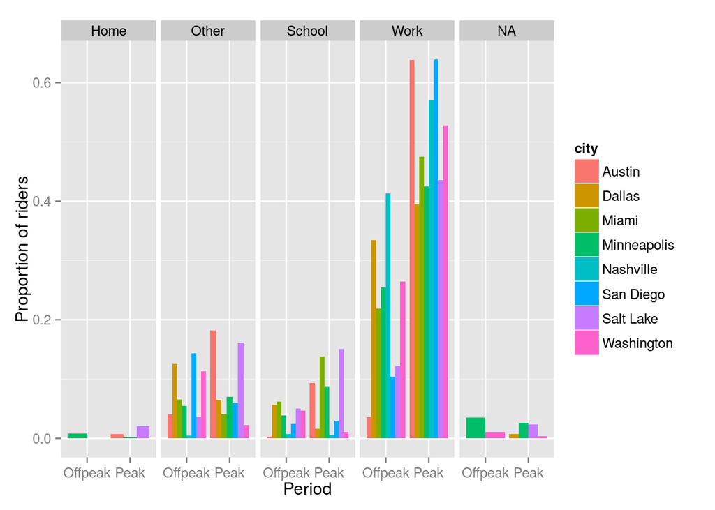

```r
ggplot(CRTsurveys, aes(x = period, fill = city, weight = cityweight)) +
  geom_bar(position = "dodge", aes(y = ..count.., group = city)) +
  facet_grid(~ atype) +
  xlab("Period") + ylab("Proportion of riders")
```